# Tugas-Pertemuan-2

## Akurasi Data Train

```r
SSEtrainsesh <- data.sesh$SSE
MSEtrainsesh <- SSEtrainsesh/length(train.ts)
RMSEtrainsesh <- sqrt(MSEtrainsesh)

akurasitrainsesh <- matrix(c(SSEtrainsesh, MSEtrainsesh, RMSEtrainsesh))
rownames(akurasitrainsesh) <- c("SSE", "MSE", "RMSE")
colnames(akurasitrainsesh) <- c("Akurasi Data Train SES alpha optimum")
akurasitrainsesh
```

```
##      Akurasi Data Train SES alpha optimum
## SSE                           9391.418679
## MSE                             93.914187
## RMSE                             9.690933
```

## Akurasi Data Test

```r
eopt <- as.numeric(data.ramalsesh$mean)[1:25]- as.numeric(testing.ts$pm10)
SSEtestsesh <- sum(eopt^2,  na.rm = TRUE)
MSEtestsesh  <- mean(eopt^2, na.rm = TRUE)
RMSEtestsesh <- sqrt(MSEtestsesh)

akurasitestsesh <- matrix(c(SSEtestsesh, MSEtestsesh, RMSEtestsesh))
rownames(akurasitestsesh) <- c("SSE", "MSE", "RMSE")
colnames(akurasitestsesh) <- c("Akurasi Data Test SES alpha optimum")
akurasitestsesh
```

```
##      Akurasi Data Test SES alpha optimum
## SSE                          2112.345046
## MSE                            84.493802
## RMSE                            9.192051
```

## Akurasi Gabungan

```r
akurasiseshgab <- accuracy(data.ramalsesh, testing.ts$pm10)
akurasiseshgab
```

```
##                      ME     RMSE      MAE       MPE     MAPE      MASE
## Training set -0.4376002 9.739754 7.105846 -5.235691 17.79221 0.9342348
## Test set      0.8603498 9.192051 7.293642 -4.146280 20.82153 0.9589250
##                    ACF1
## Training set 0.07408299
## Test set             NA
```

# Double Exponential Smoothing

## Pemulusan dan Peramalan dengan DES alpha dan beta optimum

### Fungsi HoltWinters

```r
data.desh <- HoltWinters(train.ts, alpha = NULL, beta = NULL, gamma = FALSE)
data.desh
```

```
## Holt-Winters exponential smoothing with trend and without seasonal component.
##
## Call:
## HoltWinters(x = train.ts, alpha = NULL, beta = NULL, gamma = FALSE)
##
## Smoothing parameters:
##  alpha: 0.6630386
##  beta : 0.01141283
##  gamma: FALSE
##
## Coefficients:
##         [,1]
## a 37.9860954
## b  0.1498045
```

```r
data.ramaldesh <- forecast(data.desh, h = 25)
data.ramaldesh
```

```
##     Point Forecast      Lo 80    Hi 80       Lo 95     Hi 95
## 101       38.13590 25.4496223 50.82218  18.7339126  57.53789
## 102       38.28570 23.0109197 53.56049  14.9249372  61.64647
## 103       38.43551 20.9044195 55.96660  11.6240215  65.24700
## 104       38.58531 19.0144113 58.15622   8.6542017  68.51642
## 105       38.73512 17.2786312 60.19160   5.9202533  71.54998
## 106       38.88492 15.6590883 62.11076   3.3640746  74.40577
## 107       39.03473 14.1306253 63.93883   0.9471904  77.12226
## 108       39.18453 12.6755898 65.69347  -1.3573960  79.72646
## 109       39.33434 11.2810489 67.38762  -3.5694640  82.23813
## 110       39.48414  9.9372031 69.03108  -5.7040004  84.67228
## 111       39.63394  8.6364259 70.63146  -7.7726691  87.04056
## 112       39.78375  7.3726497 72.19485  -9.7847497  89.35225
## 113       39.93355  6.1409580 73.72615 -11.7477613  91.61487
## 114       40.08336  4.9373050 75.22941 -13.6678915  93.83461
## 115       40.23316  3.7583164 76.70801 -15.5503006  96.01662
## 116       40.38297  2.6011460 78.16479 -17.3993417  98.16528
## 117       40.53277  1.4633682 79.60217 -19.2187244 100.28427
## 118       40.68258  0.3428974 81.02225 -21.0116383 102.37679
## 119       40.83238 -0.7620735 82.42683 -22.7808471 104.44561
## 120       40.98218 -1.8531218 83.81749 -24.5287632 106.49313
## 121       41.13199 -2.9316329 85.19561 -26.2575053 108.52148
## 122       41.28179 -3.9988307 86.56242 -27.9689451 110.53253
## 123       41.43160 -5.0558018 87.91900 -29.6647447 112.52794
## 124       41.58140 -6.1035161 89.26632 -31.3463871 114.50919
## 125       41.73121 -7.1428425 90.60526 -33.0152013 116.47761
```

Data pemulusan dan peramalan dengan double exponential smoothing (DES) menggunakan alpha dan beta optimum yang diperoleh dari fungsi HoltWinters(). Nilai alpha optimum yang diperoleh adalah 0.66, sedangkan nilai beta optimum adalah 0.01.

## Visualisasi Data Aktual, Pemulusan, dan Peramalan

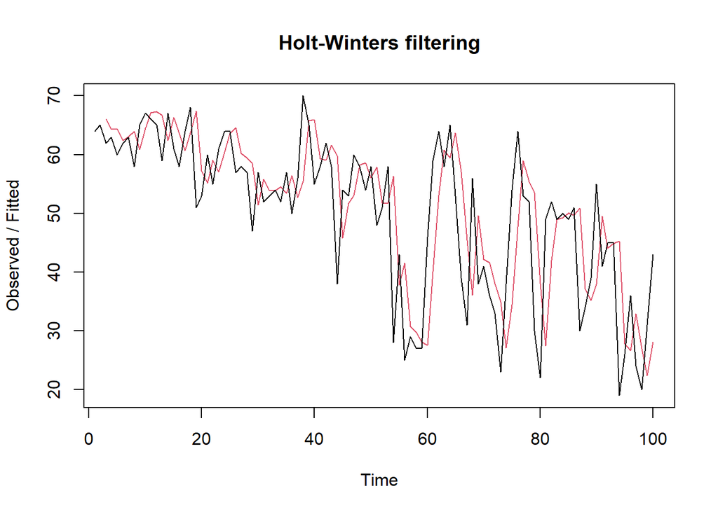

```r
plot(data.desh)
```

## Akurasi Data Train

```r
SSEtraindesh <- data.desh$SSE
MSEtraindesh <- SSEtraindesh/length(train.ts)
RMSEtraindesh <- sqrt(MSEtraindesh)

akurasitraindesh <- matrix(c(SSEtraindesh, MSEtraindesh, RMSEtraindesh))
rownames(akurasitraindesh) <- c("SSE", "MSE", "RMSE")
colnames(akurasitraindesh) <- c("Akurasi Data Train DES alpha dan beta optimum")
akurasitraindesh
```

```
##      Akurasi Data Train DES alpha dan beta optimum
## SSE                                    9634.156271
## MSE                                      96.341563
## RMSE                                      9.815374
```

## Akurasi Data Test

```r
eopt2 <- as.numeric(data.ramaldesh$mean)[1:25]- as.numeric(testing.ts$pm10)
SSEtestdesh <- sum(eopt2^2,  na.rm = TRUE)
MSEtestdesh  <- mean(eopt2^2, na.rm = TRUE)
RMSEtestdesh <- sqrt(MSEtestdesh)

akurasitestdesh <- matrix(c(SSEtestdesh, MSEtestdesh, RMSEtestdesh))
rownames(akurasitestdesh) <- c("SSE", "MSE", "RMSE")
colnames(akurasitestdesh) <- c("Akurasi Data Test DES alpha dan beta optimum")
akurasitestdesh
```

```
##      Akurasi Data Test DES alpha dan beta optimum
## SSE                                   2077.077362
## MSE                                     83.083094
## RMSE                                     9.114993
```

## Akurasi Gabungan

```r
akurasideshgab <- accuracy(data.ramaldesh, testing.ts$pm10)
akurasideshgab
```

```
##                     ME     RMSE      MAE        MPE     MAPE      MASE
## Training set -1.146464 9.915025 7.279005  -6.506281 18.24108 0.9570006
## Test set     -1.853553 9.114993 7.486632 -11.496258 22.66060 0.9842983
##                    ACF1
## Training set 0.04362552
## Test set             NA
```

# Perbandingan Hasil Peramalan (MSE)

```r
akurasitrain <- cbind(akurasitrainsma[2,1],akurasitraindma[2,1],akurasitrainsesh[2,1],akurasitraindesh[2,1])
akurasitest <- cbind(akurasitestsma[2,1],akurasitestdma[2,1],akurasitestsesh[2,1],akurasitestdesh[2,1])

perbandinganmse <- rbind(akurasitrain, akurasitest)
rownames(perbandinganmse) <- c("MSE Data Train", "MSE Data Test")
colnames(perbandinganmse) <- c("SMA n=5", "DMA n=5", "SES alpha optimum", "DES alpha dan beta optimum")
perbandinganmse
```

```
##                 SMA n=5  DMA n=5 SES alpha optimum DES alpha dan beta optimum
## MSE Data Train 126.8594 191.2280          93.91419                   96.34156
## MSE Data Test  136.7520  90.0372          84.49380                   83.08309
```

Dari semua metode yang saya gunakan, setelah dibandingkan dengan MSE, diperoleh bahwa metode yang lebih baik adalah SES Holtwinters pada data train dan DES Holtwinters pada data test. Hal ini karena kedua metode tersebut menghasilkan nilai MSE yang paling kecil dibandingkan metode lainnya.

Meski begitu, nilai MSE nya masih terbilang tinggi, sehingga model yang dihasilkan belum bisa dikatakan baik. Hal ini mungkin saja karena

1. Data yang digunakan merupakan hasil cut dari banyak data lain, mungkin saja pemotongannya kurang pas
2. Metode yang digunakan kurang cocok dengan pola data aktualnya
3. Penentuan pembagian data train dan test kurang optimal
4. Faktor lain yang belum saya pelajari